# Results

Perform a simple linear regression analysis with the participants' **VO2 Max** as the **dependent** variable and their **BMI** as the **independent** variable.

# Correlation Matrix

| Correlation Matrix | Correlation Matrix | Correlation Matrix | Correlation Matrix | Correlation Matrix VO2_Max | Correlation Matrix VO2_Max | Correlation Matrix BMI | Correlation Matrix BMI |
| --- | --- | --- | --- | --- | --- | --- | --- |
| VO2_Max |  | Pearson's r |  | — |  |  |  |
|  |  | df |  | — |  |  |  |
|  |  | p-value |  | — |  |  |  |
|  |  | N |  | — |  |  |  |
| BMI |  | Pearson's r |  | -0.813 | *** | — |  |
|  |  | df |  | 48 |  | — |  |
|  |  | p-value |  | < .001 |  | — |  |
|  |  | N |  | 50 |  | — |  |

Note. * p < .05, ** p < .01, *** p < .001

## Plot

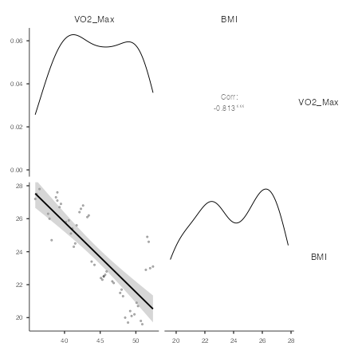

# Linear Regression

| Model Fit Measures Model | Model Fit Measures Model | Model Fit Measures R | Model Fit Measures R | Model Fit Measures R² | Model Fit Measures R² | Model Fit Measures Overall Model Test F | Model Fit Measures Overall Model Test F | Model Fit Measures Overall Model Test df1 | Model Fit Measures Overall Model Test df1 | Model Fit Measures Overall Model Test df2 | Model Fit Measures Overall Model Test df2 | Model Fit Measures Overall Model Test p | Model Fit Measures Overall Model Test p |
| --- | --- | --- | --- | --- | --- | --- | --- | --- | --- | --- | --- | --- | --- |
| 1 |  | 0.813 |  | 0.662 |  | 93.8 |  | 1 |  | 48 |  | < .001 |  |

| Model Coefficients - VO2_Max Predictor | Model Coefficients - VO2_Max Predictor | Model Coefficients - VO2_Max Estimate | Model Coefficients - VO2_Max Estimate | Model Coefficients - VO2_Max SE | Model Coefficients - VO2_Max SE | Model Coefficients - VO2_Max t | Model Coefficients - VO2_Max t | Model Coefficients - VO2_Max p | Model Coefficients - VO2_Max p |
| --- | --- | --- | --- | --- | --- | --- | --- | --- | --- |
| Intercept |  | 81.73 |  | 3.867 |  | 21.14 |  | < .001 |  |
| BMI |  | -1.56 |  | 0.161 |  | -9.69 |  | < .001 |  |

#### Data Summary

Diagnostics: [Outliers](https://drfurtado.github.io/kin610/slides/lec-8.html#checking-for-outliers)

- Identifying Outliers
  - A general rule of thumb: Cook’s distance greater than 1 is often considered large
- What if the value is greater than 1?
  - remove the outlier and run the regression again
  - How? In jamovi you can save the Cook’s distance values to the dataset, then draw a boxplot of the Cook’s distance values to identify the specific outliers.

| Cook's Distance Mean | Cook's Distance Mean | Cook's Distance Median | Cook's Distance Median | Cook's Distance SD | Cook's Distance SD | Cook's Distance Range Min | Cook's Distance Range Min | Cook's Distance Range Max | Cook's Distance Range Max |
| --- | --- | --- | --- | --- | --- | --- | --- | --- | --- |
| 0.0144 |  | 0.00322 |  | 0.0240 |  | 2.37e-5 |  | 0.112 |  |

#### Assumption Checks

| Collinearity Statistics | Collinearity Statistics | Collinearity Statistics VIF | Collinearity Statistics VIF | Collinearity Statistics Tolerance | Collinearity Statistics Tolerance |
| --- | --- | --- | --- | --- | --- |
| BMI |  | 1.00 |  | 1.00 |  |

[3]

- In Jamovi, click on the ‘Collinearity’ checkbox in the ‘Regression’ - ‘Assumptions’ options to see VIF values.
- Interpreting VIF
  - A VIF of 1 means no correlation among the predictor and the remaining predictor variables
  - VIFs exceeding 4 warrant further investigation
  - VIFs exceeding 10 are signs of serious multicollinearity requiring correction

| Normality Test (Shapiro-Wilk) Statistic | Normality Test (Shapiro-Wilk) Statistic | Normality Test (Shapiro-Wilk) p | Normality Test (Shapiro-Wilk) p |
| --- | --- | --- | --- |
| 0.840 |  | < .001 |  |

Diagnostics - [Normality](https://drfurtado.github.io/kin610/slides/lec-8.html#checking-for-normality-residuals)

- In Jamovi, you can draw a QQ-plot via the ‘Assumption Checks’ - ‘Assumption Checks’ - ‘Q-Q plot of residuals’ option.

##### Q-Q Plot

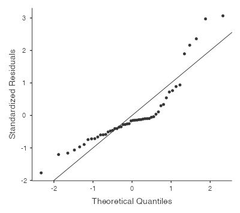

Interpreting Results

- The output shows the standardized residuals plotted as a function of their theoretical quantiles according to the regression model. The dots should be somewhat near the line.

##### Residuals Plots

Diagnostics - [Normality](https://drfurtado.github.io/kin610/slides/lec-8.html#checking-for-normality-residuals)

- In Jamovi, you can use the ‘Residuals Plots’ option to check the relationship between predicted values and residuals.
- The output provides a scatterplot for each `predictor variable`, the `outcome variable`, and the `predicted values` against residuals.

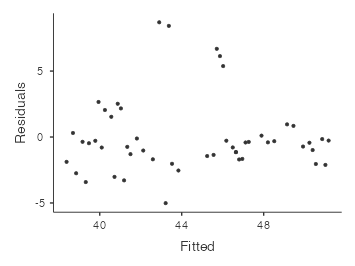

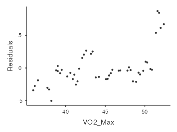

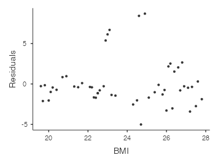

Interpreting Results

# Scatterplot

Diagnostics check -[Linearity](https://drfurtado.github.io/kin610/slides/lec-8.html#checking-for-linearity)  
Plotting Relationships

- One way to check for linearity is to plot the relationship between `predicted` values and `observed` values for the outcome variable.

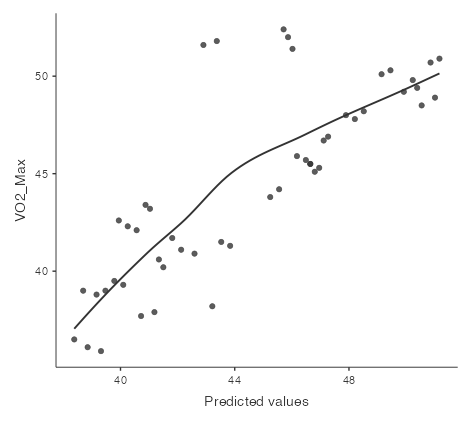

Interpreting Results

- If the plot looks approximately linear, then it suggests that your model is not doing too badly. However, if there are big departures from linearity, it suggests that changes need to be made.

# Scatterplot

Diagnostics check -[Linearity](https://drfurtado.github.io/kin610/slides/lec-8.html#checking-for-linearity)  
To get a more detailed picture of linearity, it can be helpful to look at the relationship between predicted values and residuals.

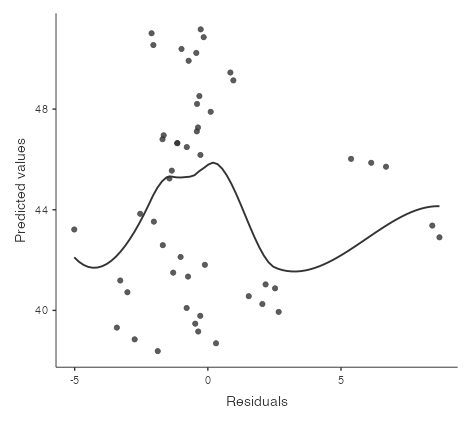

Interpreting Results

- Ideally, the relationship between predicted values and residuals should be a straight, perfectly horizontal line. In practice, we’re looking for a reasonably straight or flat line. This is a matter of judgement.

# Scatterplot

Diagnostics: [Equal Variance](https://drfurtado.github.io/kin610/slides/lec-8.html#checking-for-equality-of-variance)  
Plotting Equality of Variance in Jamovi

- To check this assumption in Jamovi, first calculate the square root of the absolute size of the residual.
  - Compute this new variable using the formula `SQRT(ABS(Residuals))`
- Then plot this against the predicted values.

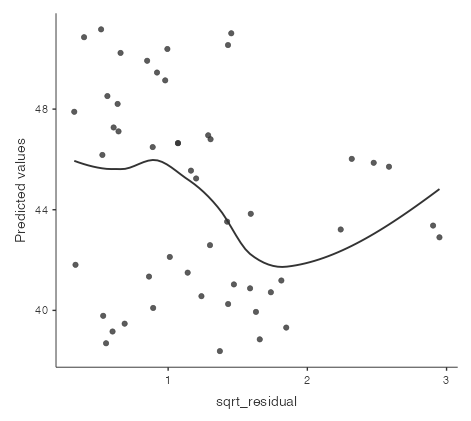

Interpretation

- The plot should show a straight horizontal line running through the middle.

# References

[1] The jamovi project (2022). *jamovi*. (Version 2.3) [Computer Software]. Retrieved from https://www.jamovi.org.

[2] R Core Team (2021). *R: A Language and environment for statistical computing*. (Version 4.1) [Computer software]. Retrieved from https://cran.r-project.org. (R packages retrieved from MRAN snapshot 2022-01-01).

[3] Fox, J., & Weisberg, S. (2020). *car: Companion to Applied Regression*. [R package]. Retrieved from https://cran.r-project.org/package=car.